# Homework 5

## Question 0

Type the following:

I will not copy and paste anything from this homework assignment page into my own solutions because if I do there is a high probability that my R Markdown file will not render correctly

## Question 1

Suppose we collect a sample of elephant tusks and, regarding their length find that in our sample of $n = 20$ we have

$$\overline{x} = 128\text{cm}, \qquad \hat{\sigma} = 12\text{cm}$$

**Part A** Several means have been proposed to be the true mean. For each of the means provided below, compute the $t$-statistic associated with the sample mean:

- $\mu_0 = 125$
- $\mu_0 = 132$
- $\mu_0 = 115$

**Part B** Suppose we are wanting to test our hypothesis with 90% confidence. Find the critical values of the appropriate $t$-distribution that mark the bounds of where 90% of our data should lie

**Part C** Which of the hypothesized means in **Part A** fell within the bounds of the 90% critical values? Which were outside the bounds? Justify your answer with the appropriate test statistics.

**Part D** Reflecting on **Part C**, what does it mean if our t-statistic falls within the bounds of our critical values? Does this mean that $\mu_0$ is likely true? Why or why not?

**Part E** Reflecting on **Part D**, what conclusions can you come to if our data is consistent with multiple hypotheses? Why do we say that we “fail to reject the null hypothesis” instead of “accepting the null hypothesis”?

## Question 2

The Happy Planet dataset includes a number of indices of well-being across 143 countries. One of these indices, Life Expectancy, is visualized in the histogram below.

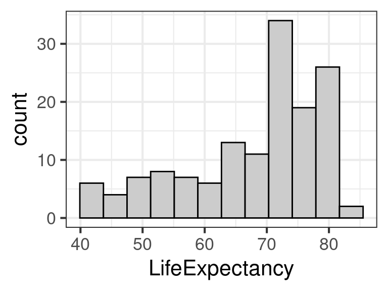

We are interested in determining the *proportion* of countries in which the average life expectancy is greater than 70 years. To this end, we collected two different samples:

- **Sample 1:** 13 countries had life expectancy greater than 70, 12 did not
- **Sample 2:** 16 countries had life expectancy greater than 70, 14 did not

Use this information to answer the following questions

**Part A** Find the estimated proportion and standard error for each of the samples provided.

**Part B** Which sample provides more evidence against the null hypothesis $H_0: p_0 = 0.725$?

## Question 3

This question uses the `penguin` dataset

```r
penguin <- read.csv("https://collinn.github.io/data/penguins.csv")
```

**Part A** Use the appropriate dplyr functions to:

- Subset the dataset to include only Chinstrap penguins
- Create a new variable called `flipper_size` that takes the value `"Large"` if the flipper is larger than the median flipper length and `"Small"` if it flipper is smaller or less than the median

Then, create a table of the data tabulating sex and size

**Part B** What proportion of female penguins are considered small? What proportion are considered large?

**Part C** Construct an 80% confidence interval on the difference in proportion of large flippers between male and female penguins. Based on this, does there appear to be evidence that the proportion of large flippers is the same in each sex?

**Part D** Create a t-statistic for this difference in proportion. If $H_0: p_1 = p_2$, would you reject or fail to reject $H_0$ for a Type I error rate of 5% (i.e., critical values from 95% confidence)